# **Problem Statement**

## **Business Context**

Workplace safety in hazardous environments like construction sites and industrial plants is crucial to prevent accidents and injuries. One of the most important safety measures is ensuring workers wear safety helmets, which protect against head injuries from falling objects and machinery. Non-compliance with helmet regulations increases the risk of serious injuries or fatalities, making effective monitoring essential, especially in large-scale operations where manual oversight is prone to errors and inefficiency.

To overcome these challenges, SafeGuard Corp plans to develop an automated image analysis system capable of detecting whether workers are wearing safety helmets. This system will improve safety enforcement, ensuring compliance and reducing the risk of head injuries. By automating helmet monitoring, SafeGuard aims to enhance efficiency, scalability, and accuracy, ultimately fostering a safer work environment while minimizing human error in safety oversight.

## **Objective**

As a data scientist at SafeGuard Corp, you are tasked with developing an image classification model that classifies images into one of two categories:

- **With Helmet:** Workers wearing safety helmets.
- **Without Helmet:** Workers not wearing safety helmets.

## **Data Description**

The dataset consists of **4125 images**, divided into two categories:

- **With Helmet:** 3161 images showing workers wearing helmets.
- **Without Helmet:** 964 images showing workers not wearing helmets.

**Dataset Characteristics:**

- **Variations in Conditions:** Images include diverse environments such as construction sites, factories, and industrial settings, with variations in lighting, angles, and worker postures to simulate real-world conditions.
- **Worker Activities:** Workers are depicted in different actions such as standing, using tools, or moving, ensuring robust model learning for various scenarios.

# **Installing and Importing the Necessary Libraries**

```python
!pip install tensorflow[and-cuda] scikit-learn==1.6.1 opencv-python==4.12.0.88 seaborn==0.13.2 matplotlib==3.10.0 numpy==2.0.2 pandas==2.2.2 -q
```

```python
import os
import random
import numpy as np                                                                               # Importing numpy for Matrix Operations
import pandas as pd
import seaborn as sns
import matplotlib.image as mpimg                                                                              # Importing pandas to read CSV files
import matplotlib.pyplot as plt                                                                  # Importting matplotlib for Plotting and visualizing images
import math                                                                                      # Importing math module to perform mathematical operations
import cv2


# Tensorflow modules
import keras
import tensorflow as tf
from tensorflow.keras.preprocessing.image import ImageDataGenerator                              # Importing the ImageDataGenerator for data augmentation
from tensorflow.keras.models import Sequential                                                   # Importing the sequential module to define a sequential model
from tensorflow.keras.layers import Dense,Dropout,Flatten,Conv2D,MaxPooling2D,BatchNormalization # Defining all the layers to build our CNN Model
from tensorflow.keras.optimizers import Adam,SGD                                                 # Importing the optimizers which can be used in our model
from sklearn import preprocessing                                                                # Importing the preprocessing module to preprocess the data
from sklearn.model_selection import train_test_split                                             # Importing train_test_split function to split the data into train and test
from sklearn.metrics import confusion_matrix
from tensorflow.keras.models import Model
from keras.applications.vgg16 import VGG16                                               # Importing confusion_matrix to plot the confusion matrix

# Display images using OpenCV
from google.colab.patches import cv2_imshow

#Imports functions for evaluating the performance of machine learning models
from sklearn.metrics import confusion_matrix, f1_score,accuracy_score, recall_score, precision_score, classification_report
from sklearn.metrics import mean_squared_error as mse                                                 # Importing cv2_imshow from google.patches to display images

# Ignore warnings
import warnings
warnings.filterwarnings('ignore')
```

```python
print("Num GPUs Available:", len(tf.config.list_physical_devices('GPU')))
print(tf.__version__)
```

```
Num GPUs Available: 1
2.19.0
```

```python
# 1. Set Python random seed
random.seed(812)

# 2. Set NumPy random seed
np.random.seed(812)

# 3. Set TensorFlow seed (covers Keras + backend)
tf.keras.utils.set_random_seed(812)

# 4. Enable deterministic GPU ops (if using GPU)
tf.config.experimental.enable_op_determinism()
```

```python
from google.colab import drive
drive.mount('/content/drive')
```

# **Data Overview**

## Loading the data

```python
# Load the image file of the dataset
images = np.load('/content/drive/MyDrive/Colab Notebooks/images.npy')

# Load the labels file of the dataset
labels = pd.read_csv('/content/drive/MyDrive/Colab Notebooks/labels.csv')
```

```python
print(images.shape)
print(labels.shape)
```

```
(4125, 200, 200, 3)
(4125, 1)
```

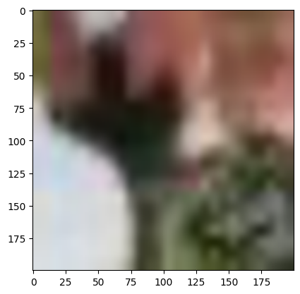

```python
plt.imshow(images[5]);
```

# **Exploratory Data Analysis**

### Plot random images from each of the classes and print their corresponding labels.

```python
# Converting the images from BGR to RGB using cvtColor function of OpenCV
for i in range(len(images)):
  images[i] = cv2.cvtColor(images[i], cv2.COLOR_BGR2RGB)
```

```python
def plot_images(images,labels):
  num_classes=10                                                                  # Number of Classes
  categories=np.unique(labels)
  keys=dict(labels['label'])                                                      # Obtaing the unique classes from y_train
  rows = 3                                                                        # Defining number of rows=3
  cols = 4                                                                        # Defining number of columns=4
  fig = plt.figure(figsize=(10, 8))                                               # Defining the figure size to 10x8
  for i in range(cols):
      for j in range(rows):
          random_index = np.random.randint(0, len(labels))                        # Generating random indices from the data and plotting the images
          ax = fig.add_subplot(rows, cols, i * rows + j + 1)                      # Adding subplots with 3 rows and 4 columns
          ax.imshow(images[random_index, :])                                      # Plotting the image
          ax.set_title(keys[random_index])
  plt.show()
```

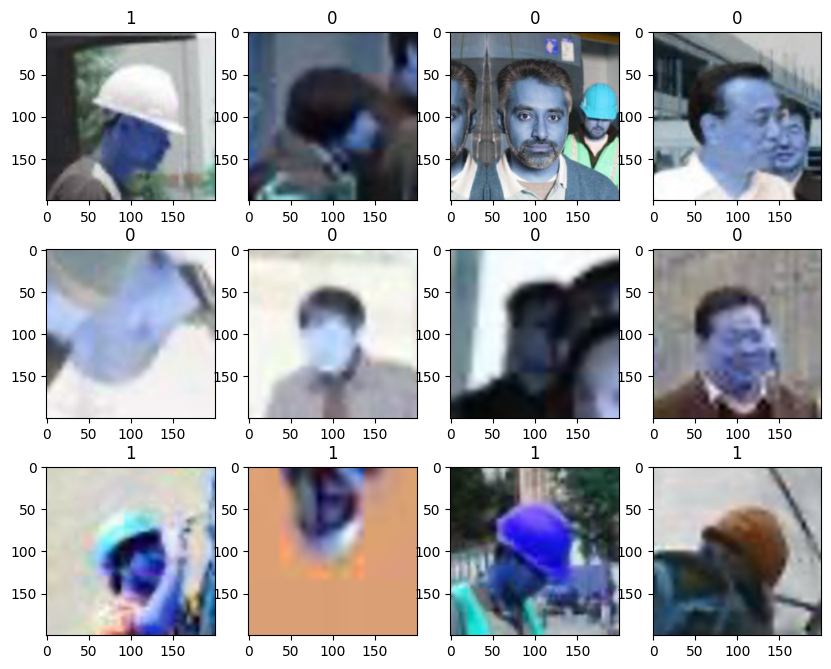

```python
plot_images(images,labels)
```

## Checking for class imbalance

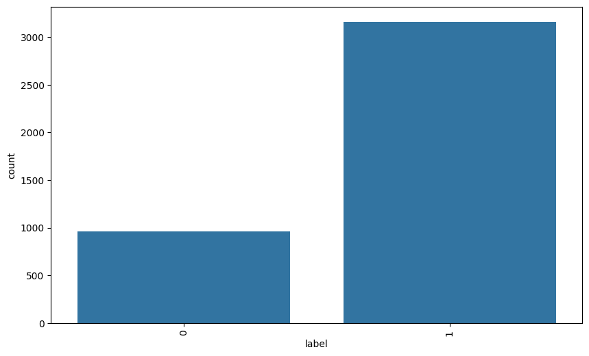

```python
plt.figure(figsize=(10,6))
sns.countplot(x=labels['label'])
plt.xticks(rotation='vertical')
plt.show()
```

# **Data Preprocessing**

```python
images_decreased = []
height = 64
width = 64
dimensions = (width, height)
for i in range(len(images)):
  images_decreased.append(cv2.resize(images[i], dimensions, interpolation=cv2.INTER_LINEAR))
```

[figure not shown]

```python
plt.imshow(images_decreased[3]);
```

```python
# Applying Gaussian Blur to denoise the images
images_gb=[]
for i in range(len(images_decreased)):
    images_gb.append(cv2.GaussianBlur(images_decreased[i], ksize =(3,3),sigmaX =  0))
```

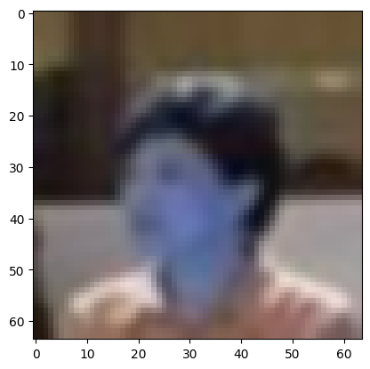

```python
plt.imshow(images_gb[3]);
```

### Splitting the dataset

```python
X_train, X_temp, y_train, y_temp = train_test_split(np.array(images_decreased),labels , test_size=0.2, random_state=42,stratify=labels)
X_val, X_test, y_val, y_test = train_test_split(X_temp,y_temp , test_size=0.5, random_state=42,stratify=y_temp)
```

```python
print(X_train.shape,y_train.shape)
print(X_val.shape,y_val.shape)
print(X_test.shape,y_test.shape)
```

```
(3300, 64, 64, 3) (3300, 1)
(412, 64, 64, 3) (412, 1)
(413, 64, 64, 3) (413, 1)
```

### Data Normalization

```python
from sklearn.preprocessing import LabelBinarizer
enc = LabelBinarizer()
y_train_encoded = enc.fit_transform(y_train)
y_val_encoded=enc.transform(y_val)
y_test_encoded=enc.transform(y_test)
```

```python
y_train_encoded[0]
```

```
array([1])
```

# **Model Building**

## Model Evaluation Criterion

```python
# defining a function to compute different metrics to check performance of a classification model built using statsmodels
def model_performance_classification(model, predictors, target):
    """
    Function to compute different metrics to check classification model performance

    model: classifier
    predictors: independent variables
    target: dependent variable
    """

    # checking which probabilities are greater than threshold
    pred = model.predict(predictors).reshape(-1)>0.5

    # If the target is a pandas DataFrame/Series, convert to numpy array
    if isinstance(target, pd.DataFrame) or isinstance(target, pd.Series):
        target = target.to_numpy().reshape(-1)
    else:
        target = target.reshape(-1)


    acc = accuracy_score(target, pred)  # to compute Accuracy
    recall = recall_score(target, pred, average='micro')  # to compute Recall
    precision = precision_score(target, pred, average='micro')  # to compute Precision
    f1 = f1_score(target, pred, average='micro')  # to compute F1-score

    # creating a dataframe of metrics
    df_perf = pd.DataFrame({"Accuracy": acc, "Recall": recall, "Precision": precision, "F1 Score": f1,},index=[0],)

    return df_perf
```

```python
def plot_confusion_matrix(model,predictors,target,ml=False):
    """
    Function to plot the confusion matrix

    model: classifier
    predictors: independent variables
    target: dependent variable
    ml: To specify if the model used is an sklearn ML model or not (True means ML model)
    """

    # checking which probabilities are greater than threshold
    pred = model.predict(predictors).reshape(-1)>0.5

    # If the target is a pandas DataFrame/Series, convert to numpy array
    if isinstance(target, pd.DataFrame) or isinstance(target, pd.Series):
        target = target.to_numpy().reshape(-1)
    else:
        target = target.reshape(-1)

    # Plotting the Confusion Matrix using confusion matrix() function which is also predefined tensorflow module
    confusion_matrix = tf.math.confusion_matrix(target,pred)
    f, ax = plt.subplots(figsize=(10, 8))
    sns.heatmap(
        confusion_matrix,
        annot=True,
        linewidths=.4,
        fmt="d",
        square=True,
        ax=ax
    )
    plt.show()
```

```python
# Normalizing the image pixels
X_train_normalized = X_train.astype('float32')/255.0
X_val_normalized = X_val.astype('float32')/255.0
X_test_normalized = X_test.astype('float32')/255.0
```

### Model : Convolutional Neural Network (CNN) from Scratch

```python
# Define the CNN architecture
cnn_model_1 = Sequential([
    Conv2D(32, (3, 3), activation='relu', input_shape=X_train.shape[1:]),
    MaxPooling2D(pool_size=(2, 2)),

    Conv2D(64, (3, 3), activation='relu'),
    MaxPooling2D(pool_size=(2, 2)),

    Flatten(),
    Dense(128, activation='relu'),
    Dropout(0.5),
    Dense(1, activation='sigmoid')  # Output layer for binary classification
])
```

```python
cnn_model_1.compile(
    optimizer='adam',
    loss='binary_crossentropy',
    metrics=['accuracy']
)
```

```python
# Display model summary
cnn_model_1.summary()
```

```
Model: "sequential"
```

```
┏━━━━━━━━━━━━━━━━━━━━━━━━━━━━━━━━━┳━━━━━━━━━━━━━━━━━━━━━━━━┳━━━━━━━━━━━━━━━┓
┃ Layer (type)                    ┃ Output Shape           ┃       Param # ┃
┡━━━━━━━━━━━━━━━━━━━━━━━━━━━━━━━━━╇━━━━━━━━━━━━━━━━━━━━━━━━╇━━━━━━━━━━━━━━━┩
│ conv2d (Conv2D)                 │ (None, 62, 62, 32)     │           896 │
├─────────────────────────────────┼────────────────────────┼───────────────┤
│ max_pooling2d (MaxPooling2D)    │ (None, 31, 31, 32)     │             0 │
├─────────────────────────────────┼────────────────────────┼───────────────┤
│ conv2d_1 (Conv2D)               │ (None, 29, 29, 64)     │        18,496 │
├─────────────────────────────────┼────────────────────────┼───────────────┤
│ max_pooling2d_1 (MaxPooling2D)  │ (None, 14, 14, 64)     │             0 │
├─────────────────────────────────┼────────────────────────┼───────────────┤
│ flatten (Flatten)               │ (None, 12544)          │             0 │
├─────────────────────────────────┼────────────────────────┼───────────────┤
│ dense (Dense)                   │ (None, 128)            │     1,605,760 │
├─────────────────────────────────┼────────────────────────┼───────────────┤
│ dropout (Dropout)               │ (None, 128)            │             0 │
├─────────────────────────────────┼────────────────────────┼───────────────┤
│ dense_1 (Dense)                 │ (None, 1)              │           129 │
└─────────────────────────────────┴────────────────────────┴───────────────┘
```

```
 Total params: 1,625,281 (6.20 MB)
```

```
 Trainable params: 1,625,281 (6.20 MB)
```

```
 Non-trainable params: 0 (0.00 B)
```

```python
history_1 = cnn_model_1.fit(
    X_train, y_train,
    validation_data=(X_val, y_val),
    epochs=10,
    batch_size=32,
    verbose=2
)
```

```
104/104 - 12s - 119ms/step - accuracy: 0.7982 - loss: 8.7216 - val_accuracy: 0.8762 - val_loss: 0.2610
104/104 - 1s - 8ms/step - accuracy: 0.8661 - loss: 0.3281 - val_accuracy: 0.8908 - val_loss: 0.2358
104/104 - 1s - 8ms/step - accuracy: 0.8873 - loss: 0.2678 - val_accuracy: 0.8811 - val_loss: 0.2235
104/104 - 1s - 8ms/step - accuracy: 0.9009 - loss: 0.2283 - val_accuracy: 0.8956 - val_loss: 0.2393
104/104 - 1s - 8ms/step - accuracy: 0.9097 - loss: 0.2149 - val_accuracy: 0.8932 - val_loss: 0.2676
104/104 - 1s - 8ms/step - accuracy: 0.9248 - loss: 0.1895 - val_accuracy: 0.9029 - val_loss: 0.2570
104/104 - 1s - 8ms/step - accuracy: 0.9306 - loss: 0.1655 - val_accuracy: 0.9005 - val_loss: 0.2662
104/104 - 1s - 8ms/step - accuracy: 0.9397 - loss: 0.1479 - val_accuracy: 0.8908 - val_loss: 0.2714
104/104 - 1s - 8ms/step - accuracy: 0.9348 - loss: 0.1615 - val_accuracy: 0.8859 - val_loss: 0.2504
104/104 - 1s - 8ms/step - accuracy: 0.9470 - loss: 0.1341 - val_accuracy: 0.8981 - val_loss: 0.2242
```

```python
history_1 = cnn_model_1.fit(
    X_train, y_train,
    validation_data=(X_val, y_val),
    epochs=10,
    batch_size=32,
    verbose=2
)
```

```
104/104 - 1s - 11ms/step - accuracy: 0.9470 - loss: 0.1313 - val_accuracy: 0.9102 - val_loss: 0.2675
104/104 - 1s - 11ms/step - accuracy: 0.9427 - loss: 0.1431 - val_accuracy: 0.9223 - val_loss: 0.2141
104/104 - 1s - 12ms/step - accuracy: 0.9585 - loss: 0.1061 - val_accuracy: 0.8981 - val_loss: 0.3735
104/104 - 1s - 8ms/step - accuracy: 0.9642 - loss: 0.0886 - val_accuracy: 0.9078 - val_loss: 0.2692
104/104 - 1s - 8ms/step - accuracy: 0.9676 - loss: 0.0922 - val_accuracy: 0.9272 - val_loss: 0.4105
104/104 - 1s - 8ms/step - accuracy: 0.9615 - loss: 0.0903 - val_accuracy: 0.9150 - val_loss: 0.2819
104/104 - 1s - 8ms/step - accuracy: 0.9621 - loss: 0.0933 - val_accuracy: 0.9078 - val_loss: 0.2873
104/104 - 1s - 8ms/step - accuracy: 0.9667 - loss: 0.0864 - val_accuracy: 0.9272 - val_loss: 0.2999
104/104 - 1s - 8ms/step - accuracy: 0.9745 - loss: 0.0695 - val_accuracy: 0.9078 - val_loss: 0.4388
104/104 - 1s - 8ms/step - accuracy: 0.9721 - loss: 0.0664 - val_accuracy: 0.9053 - val_loss: 0.3887
```

```python
# Evaluate on Train Set
cnn_model_1_train_perf = model_performance_classification(cnn_model_1, X_train,y_train)

print("Train performance metrics")
print(cnn_model_1_train_perf)
```

```
104/104 ━━━━━━━━━━━━━━━━━━━━ 0s 3ms/step
Train performance metrics
   Accuracy    Recall  Precision  F1 Score
0  0.988182  0.988182   0.988182  0.988182
```

```
104/104 ━━━━━━━━━━━━━━━━━━━━ 0s 2ms/step
```

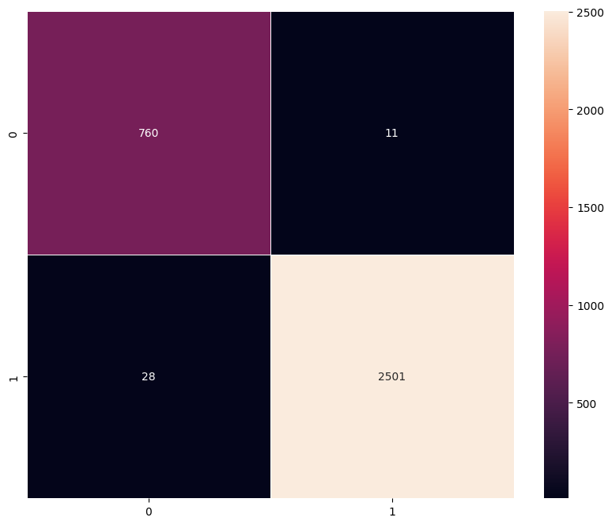

```python
plot_confusion_matrix(cnn_model_1, X_train, y_train)
```

```python
cnn_model_1_val_perf = model_performance_classification(cnn_model_1, X_val,y_val)

print("Train performance metrics")
print(cnn_model_1_val_perf)
```

```
13/13 ━━━━━━━━━━━━━━━━━━━━ 0s 4ms/step
Train performance metrics
   Accuracy   Recall  Precision  F1 Score
0   0.90534  0.90534    0.90534   0.90534
```

```
13/13 ━━━━━━━━━━━━━━━━━━━━ 0s 4ms/step
```

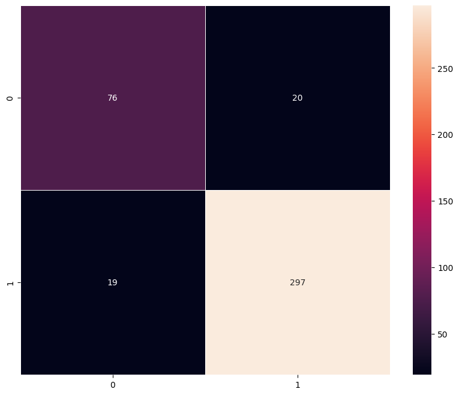

```python
plot_confusion_matrix(cnn_model_1, X_val, y_val)
```

```python
vgg_model = VGG16(weights='imagenet',include_top=False,input_shape=(64,64,3))
vgg_model.summary()
```

```
Downloading data from https://storage.googleapis.com/tensorflow/keras-applications/vgg16/vgg16_weights_tf_dim_ordering_tf_kernels_notop.h5
58889256/58889256 ━━━━━━━━━━━━━━━━━━━━ 0s 0us/step
```

```
Model: "vgg16"
```

```
┏━━━━━━━━━━━━━━━━━━━━━━━━━━━━━━━━━┳━━━━━━━━━━━━━━━━━━━━━━━━┳━━━━━━━━━━━━━━━┓
┃ Layer (type)                    ┃ Output Shape           ┃       Param # ┃
┡━━━━━━━━━━━━━━━━━━━━━━━━━━━━━━━━━╇━━━━━━━━━━━━━━━━━━━━━━━━╇━━━━━━━━━━━━━━━┩
│ input_layer_1 (InputLayer)      │ (None, 64, 64, 3)      │             0 │
├─────────────────────────────────┼────────────────────────┼───────────────┤
│ block1_conv1 (Conv2D)           │ (None, 64, 64, 64)     │         1,792 │
├─────────────────────────────────┼────────────────────────┼───────────────┤
│ block1_conv2 (Conv2D)           │ (None, 64, 64, 64)     │        36,928 │
├─────────────────────────────────┼────────────────────────┼───────────────┤
│ block1_pool (MaxPooling2D)      │ (None, 32, 32, 64)     │             0 │
├─────────────────────────────────┼────────────────────────┼───────────────┤
│ block2_conv1 (Conv2D)           │ (None, 32, 32, 128)    │        73,856 │
├─────────────────────────────────┼────────────────────────┼───────────────┤
│ block2_conv2 (Conv2D)           │ (None, 32, 32, 128)    │       147,584 │
├─────────────────────────────────┼────────────────────────┼───────────────┤
│ block2_pool (MaxPooling2D)      │ (None, 16, 16, 128)    │             0 │
├─────────────────────────────────┼────────────────────────┼───────────────┤
│ block3_conv1 (Conv2D)           │ (None, 16, 16, 256)    │       295,168 │
├─────────────────────────────────┼────────────────────────┼───────────────┤
│ block3_conv2 (Conv2D)           │ (None, 16, 16, 256)    │       590,080 │
├─────────────────────────────────┼────────────────────────┼───────────────┤
│ block3_conv3 (Conv2D)           │ (None, 16, 16, 256)    │       590,080 │
├─────────────────────────────────┼────────────────────────┼───────────────┤
│ block3_pool (MaxPooling2D)      │ (None, 8, 8, 256)      │             0 │
├─────────────────────────────────┼────────────────────────┼───────────────┤
│ block4_conv1 (Conv2D)           │ (None, 8, 8, 512)      │     1,180,160 │
├─────────────────────────────────┼────────────────────────┼───────────────┤
│ block4_conv2 (Conv2D)           │ (None, 8, 8, 512)      │     2,359,808 │
├─────────────────────────────────┼────────────────────────┼───────────────┤
│ block4_conv3 (Conv2D)           │ (None, 8, 8, 512)      │     2,359,808 │
├─────────────────────────────────┼────────────────────────┼───────────────┤
│ block4_pool (MaxPooling2D)      │ (None, 4, 4, 512)      │             0 │
├─────────────────────────────────┼────────────────────────┼───────────────┤
│ block5_conv1 (Conv2D)           │ (None, 4, 4, 512)      │     2,359,808 │
├─────────────────────────────────┼────────────────────────┼───────────────┤
│ block5_conv2 (Conv2D)           │ (None, 4, 4, 512)      │     2,359,808 │
├─────────────────────────────────┼────────────────────────┼───────────────┤
│ block5_conv3 (Conv2D)           │ (None, 4, 4, 512)      │     2,359,808 │
├─────────────────────────────────┼────────────────────────┼───────────────┤
│ block5_pool (MaxPooling2D)      │ (None, 2, 2, 512)      │             0 │
└─────────────────────────────────┴────────────────────────┴───────────────┘
```

```
 Total params: 14,714,688 (56.13 MB)
```

```
 Trainable params: 14,714,688 (56.13 MB)
```

```
 Non-trainable params: 0 (0.00 B)
```

```python
# Making all the layers of the VGG model non-trainable. i.e. freezing them
for layer in vgg_model.layers:
    layer.trainable = False
```

```python
model_1 = Sequential()

# Adding the convolutional part of the VGG16 model from above
model_1.add(vgg_model)

# Unfreeze the last few layers of the VGG16 model for fine-tuning
for layer in vgg_model.layers[-4:]:
    layer.trainable = True

# Flattening the output of the VGG16 model because it is from a convolutional layer
model_1.add(Flatten())

#Adding the Feed Forward neural network
model_1.add(Dense(256,activation='relu'))
model_1.add(Dropout(rate=0.4))
model_1.add(Dense(32,activation='relu'))

# Adding a dense output layer for binary classification
model_1.add(Dense(1, activation='sigmoid'))
```

```python
opt=Adam()
# Compile model for binary classification
model_1.compile(optimizer=opt, loss='binary_crossentropy', metrics=['accuracy'])
```

```python
# Generating the summary of the model
model_1.summary()
```

```
Model: "sequential_2"
```

```
┏━━━━━━━━━━━━━━━━━━━━━━━━━━━━━━━━━┳━━━━━━━━━━━━━━━━━━━━━━━━┳━━━━━━━━━━━━━━━┓
┃ Layer (type)                    ┃ Output Shape           ┃       Param # ┃
┡━━━━━━━━━━━━━━━━━━━━━━━━━━━━━━━━━╇━━━━━━━━━━━━━━━━━━━━━━━━╇━━━━━━━━━━━━━━━┩
│ vgg16 (Functional)              │ (None, 2, 2, 512)      │    14,714,688 │
├─────────────────────────────────┼────────────────────────┼───────────────┤
│ flatten_2 (Flatten)             │ (None, 2048)           │             0 │
├─────────────────────────────────┼────────────────────────┼───────────────┤
│ dense_5 (Dense)                 │ (None, 256)            │       524,544 │
├─────────────────────────────────┼────────────────────────┼───────────────┤
│ dropout_2 (Dropout)             │ (None, 256)            │             0 │
├─────────────────────────────────┼────────────────────────┼───────────────┤
│ dense_6 (Dense)                 │ (None, 32)             │         8,224 │
├─────────────────────────────────┼────────────────────────┼───────────────┤
│ dense_7 (Dense)                 │ (None, 1)              │            33 │
└─────────────────────────────────┴────────────────────────┴───────────────┘
```

```
 Total params: 15,247,489 (58.16 MB)
```

```
 Trainable params: 7,612,225 (29.04 MB)
```

```
 Non-trainable params: 7,635,264 (29.13 MB)
```

```python
train_datagen = ImageDataGenerator(
                              rotation_range=20,
                              fill_mode='nearest',width_shift_range=0.2,height_shift_range=0.2,shear_range=0.3,zoom_range=0.4
                              )
```

```python
# Epochs
epochs = 20
# Batch size
batch_size = 128

history_vgg16 = model_1.fit(train_datagen.flow(X_train_normalized,y_train_encoded,
                                       batch_size=batch_size,
                                       seed=42,
                                       shuffle=False),
                    epochs=epochs,
                    steps_per_epoch=X_train_normalized.shape[0] // batch_size,
                    validation_data=(X_val_normalized,y_val_encoded),
                    verbose=1)
```

```
25/25 ━━━━━━━━━━━━━━━━━━━━ 8s 244ms/step - accuracy: 0.7368 - loss: 0.5700 - val_accuracy: 0.7670 - val_loss: 0.3899
25/25 ━━━━━━━━━━━━━━━━━━━━ 0s 10ms/step - accuracy: 0.7422 - loss: 0.4405 - val_accuracy: 0.7670 - val_loss: 0.3763
25/25 ━━━━━━━━━━━━━━━━━━━━ 7s 287ms/step - accuracy: 0.7759 - loss: 0.3758 - val_accuracy: 0.8811 - val_loss: 0.2753
25/25 ━━━━━━━━━━━━━━━━━━━━ 0s 10ms/step - accuracy: 0.8203 - loss: 0.3207 - val_accuracy: 0.9005 - val_loss: 0.2695
25/25 ━━━━━━━━━━━━━━━━━━━━ 5s 212ms/step - accuracy: 0.8657 - loss: 0.3159 - val_accuracy: 0.9053 - val_loss: 0.2757
25/25 ━━━━━━━━━━━━━━━━━━━━ 0s 11ms/step - accuracy: 0.8828 - loss: 0.2764 - val_accuracy: 0.8908 - val_loss: 0.2864
25/25 ━━━━━━━━━━━━━━━━━━━━ 7s 280ms/step - accuracy: 0.9023 - loss: 0.2809 - val_accuracy: 0.9417 - val_loss: 0.2219
25/25 ━━━━━━━━━━━━━━━━━━━━ 0s 10ms/step - accuracy: 0.8984 - loss: 0.2471 - val_accuracy: 0.9393 - val_loss: 0.2200
25/25 ━━━━━━━━━━━━━━━━━━━━ 9s 226ms/step - accuracy: 0.9067 - loss: 0.2556 - val_accuracy: 0.9296 - val_loss: 0.2278
25/25 ━━━━━━━━━━━━━━━━━━━━ 0s 11ms/step - accuracy: 0.9453 - loss: 0.1664 - val_accuracy: 0.9248 - val_loss: 0.2498
25/25 ━━━━━━━━━━━━━━━━━━━━ 7s 282ms/step - accuracy: 0.9057 - loss: 0.2541 - val_accuracy: 0.9490 - val_loss: 0.1853
25/25 ━━━━━━━━━━━━━━━━━━━━ 0s 10ms/step - accuracy: 0.9609 - loss: 0.1711 - val_accuracy: 0.9466 - val_loss: 0.1914
25/25 ━━━━━━━━━━━━━━━━━━━━ 5s 212ms/step - accuracy: 0.9281 - loss: 0.1968 - val_accuracy: 0.9539 - val_loss: 0.1421
25/25 ━━━━━━━━━━━━━━━━━━━━ 0s 11ms/step - accuracy: 0.9062 - loss: 0.2279 - val_accuracy: 0.9466 - val_loss: 0.1546
25/25 ━━━━━━━━━━━━━━━━━━━━ 7s 292ms/step - accuracy: 0.9224 - loss: 0.1968 - val_accuracy: 0.9490 - val_loss: 0.1449
25/25 ━━━━━━━━━━━━━━━━━━━━ 0s 10ms/step - accuracy: 0.9297 - loss: 0.1964 - val_accuracy: 0.9466 - val_loss: 0.1479
25/25 ━━━━━━━━━━━━━━━━━━━━ 9s 241ms/step - accuracy: 0.9363 - loss: 0.1620 - val_accuracy: 0.9515 - val_loss: 0.1331
25/25 ━━━━━━━━━━━━━━━━━━━━ 1s 15ms/step - accuracy: 0.9609 - loss: 0.1084 - val_accuracy: 0.9490 - val_loss: 0.1392
25/25 ━━━━━━━━━━━━━━━━━━━━ 7s 287ms/step - accuracy: 0.9366 - loss: 0.1524 - val_accuracy: 0.9563 - val_loss: 0.1177
25/25 ━━━━━━━━━━━━━━━━━━━━ 0s 10ms/step - accuracy: 0.9375 - loss: 0.1629 - val_accuracy: 0.9539 - val_loss: 0.1231
```

### Visualizing the predictions

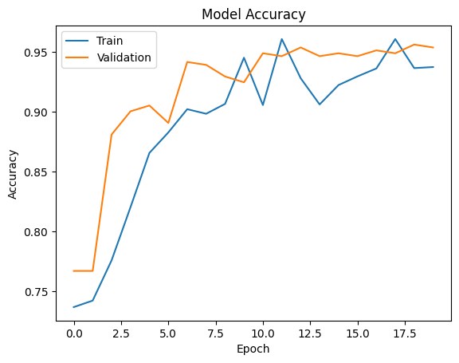

```python
plt.plot(history_vgg16.history['accuracy'])
plt.plot(history_vgg16.history['val_accuracy'])
plt.title('Model Accuracy')
plt.ylabel('Accuracy')
plt.xlabel('Epoch')
plt.legend(['Train', 'Validation'], loc='upper left')
plt.show()
```

```python
model_1_train_perf = model_performance_classification(model_1, X_train_normalized,y_train_encoded)

print("Train performance metrics")
print(model_1_train_perf)
```

```
104/104 ━━━━━━━━━━━━━━━━━━━━ 2s 17ms/step
Train performance metrics
   Accuracy    Recall  Precision  F1 Score
0  0.965152  0.965152   0.965152  0.965152
```

```
104/104 ━━━━━━━━━━━━━━━━━━━━ 2s 15ms/step
```

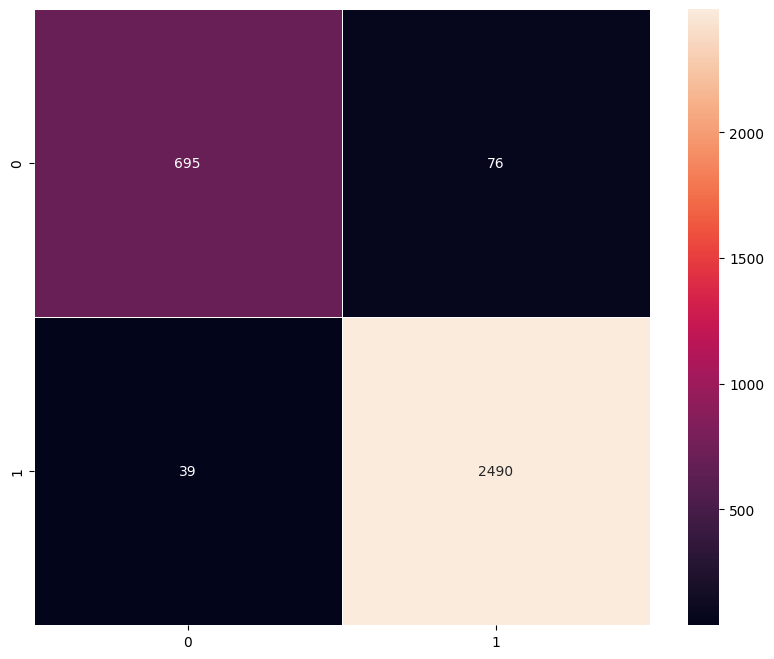

```python
plot_confusion_matrix(model_1,X_train_normalized,y_train_encoded)
```

```python
model_1_valid_perf = model_performance_classification(model_1, X_val_normalized,y_val_encoded)

print("Validation performance metrics")
print(model_1_valid_perf)
```

```
13/13 ━━━━━━━━━━━━━━━━━━━━ 0s 18ms/step
Validation performance metrics
   Accuracy    Recall  Precision  F1 Score
0  0.953883  0.953883   0.953883  0.953883
```

```
13/13 ━━━━━━━━━━━━━━━━━━━━ 0s 17ms/step
```

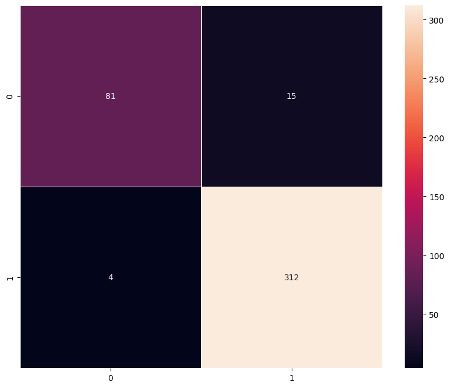

```python
plot_confusion_matrix(model_1,X_val_normalized,y_val_encoded)
```

```
1/1 ━━━━━━━━━━━━━━━━━━━━ 0s 115ms/step
Predicted Label [0]
True Label 0
```

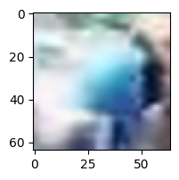

```
1/1 ━━━━━━━━━━━━━━━━━━━━ 0s 74ms/step
Predicted Label [1]
True Label 1
```

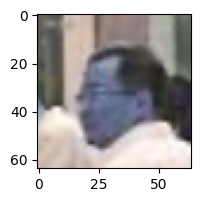

```
1/1 ━━━━━━━━━━━━━━━━━━━━ 0s 73ms/step
Predicted Label [0]
True Label 0
```

```python
# Visualizing the predicted and correct label of images from test data
plt.figure(figsize=(2,2))
plt.imshow(X_val[2])
plt.show()
print('Predicted Label', enc.inverse_transform(model_1.predict((X_val_normalized[2].reshape(1,64,64,3)))))   # reshaping the input image as we are only trying to predict using a single image
print('True Label', enc.inverse_transform(y_val_encoded)[2])                                               # using inverse_transform() to get the output label from the output vector

plt.figure(figsize=(2,2))
plt.imshow(X_val[33])
plt.show()
print('Predicted Label', enc.inverse_transform(model_1.predict((X_val_normalized[33].reshape(1,64,64,3)))))  # reshaping the input image as we are only trying to predict using a single image
print('True Label', enc.inverse_transform(y_val_encoded)[33])                                              # using inverse_transform() to get the output label from the output vector

plt.figure(figsize=(2,2))
plt.imshow(X_val[36])
plt.show()
print('Predicted Label', enc.inverse_transform(model_1.predict((X_val_normalized[36].reshape(1,64,64,3)))))  # reshaping the input image as we are only trying to predict using a single image
print('True Label', enc.inverse_transform(y_val_encoded)[36])
```

## Model 2: Transfer Learning with VGG-16 (Base+FNN)

```python
model_2 = Sequential()

# Adding the convolutional part of the VGG16 model from above
model_2.add(vgg_model)

# Flattening the output of the VGG16 model because it is from a convolutional layer
model_2.add(Flatten())

#Adding the Feed Forward neural network
model_2.add(Dense(256,activation='relu'))
model_2.add(Dropout(rate=0.4))
model_2.add(Dense(32,activation='relu'))

# Adding a dense output layer for binary classification
model_2.add(Dense(1, activation='sigmoid'))
```

```python
opt = Adam(learning_rate=0.0001) # Slightly higher learning rate for fine-tuning
```

```python
# Compile model for binary classification
model_2.compile(optimizer=opt, loss='binary_crossentropy', metrics=['accuracy'])
```

```python
# Generating the summary of the model
model_2.summary()
```

```
Model: "sequential_3"
```

```
┏━━━━━━━━━━━━━━━━━━━━━━━━━━━━━━━━━┳━━━━━━━━━━━━━━━━━━━━━━━━┳━━━━━━━━━━━━━━━┓
┃ Layer (type)                    ┃ Output Shape           ┃       Param # ┃
┡━━━━━━━━━━━━━━━━━━━━━━━━━━━━━━━━━╇━━━━━━━━━━━━━━━━━━━━━━━━╇━━━━━━━━━━━━━━━┩
│ vgg16 (Functional)              │ (None, 2, 2, 512)      │    14,714,688 │
├─────────────────────────────────┼────────────────────────┼───────────────┤
│ flatten_3 (Flatten)             │ (None, 2048)           │             0 │
├─────────────────────────────────┼────────────────────────┼───────────────┤
│ dense_8 (Dense)                 │ (None, 256)            │       524,544 │
├─────────────────────────────────┼────────────────────────┼───────────────┤
│ dropout_3 (Dropout)             │ (None, 256)            │             0 │
├─────────────────────────────────┼────────────────────────┼───────────────┤
│ dense_9 (Dense)                 │ (None, 32)             │         8,224 │
├─────────────────────────────────┼────────────────────────┼───────────────┤
│ dense_10 (Dense)                │ (None, 1)              │            33 │
└─────────────────────────────────┴────────────────────────┴───────────────┘
```

```
 Total params: 15,247,489 (58.16 MB)
```

```
 Trainable params: 7,612,225 (29.04 MB)
```

```
 Non-trainable params: 7,635,264 (29.13 MB)
```

```python
history_vgg16 = model_2.fit(train_datagen.flow(X_train_normalized,y_train_encoded,
                                       batch_size=batch_size,
                                       seed=42,
                                       shuffle=False),
                    epochs=50, # Increase epochs for fine-tuning
                    steps_per_epoch=X_train_normalized.shape[0] // batch_size,
                    validation_data=(X_val_normalized,y_val_encoded),
                    verbose=1)
```

```
25/25 ━━━━━━━━━━━━━━━━━━━━ 9s 251ms/step - accuracy: 0.8641 - loss: 0.2632 - val_accuracy: 0.9442 - val_loss: 0.2396
25/25 ━━━━━━━━━━━━━━━━━━━━ 0s 11ms/step - accuracy: 0.9453 - loss: 0.2045 - val_accuracy: 0.9466 - val_loss: 0.2390
25/25 ━━━━━━━━━━━━━━━━━━━━ 8s 331ms/step - accuracy: 0.9404 - loss: 0.2291 - val_accuracy: 0.9612 - val_loss: 0.2292
25/25 ━━━━━━━━━━━━━━━━━━━━ 0s 11ms/step - accuracy: 0.9531 - loss: 0.2284 - val_accuracy: 0.9612 - val_loss: 0.2293
25/25 ━━━━━━━━━━━━━━━━━━━━ 5s 213ms/step - accuracy: 0.9505 - loss: 0.2021 - val_accuracy: 0.9587 - val_loss: 0.2093
25/25 ━━━━━━━━━━━━━━━━━━━━ 0s 10ms/step - accuracy: 0.9766 - loss: 0.1501 - val_accuracy: 0.9587 - val_loss: 0.2031
25/25 ━━━━━━━━━━━━━━━━━━━━ 7s 285ms/step - accuracy: 0.9590 - loss: 0.1433 - val_accuracy: 0.9587 - val_loss: 0.1737
25/25 ━━━━━━━━━━━━━━━━━━━━ 0s 11ms/step - accuracy: 0.9688 - loss: 0.0975 - val_accuracy: 0.9563 - val_loss: 0.1786
25/25 ━━━━━━━━━━━━━━━━━━━━ 5s 214ms/step - accuracy: 0.9524 - loss: 0.1167 - val_accuracy: 0.9587 - val_loss: 0.1289
25/25 ━━━━━━━━━━━━━━━━━━━━ 0s 11ms/step - accuracy: 0.9531 - loss: 0.0991 - val_accuracy: 0.9563 - val_loss: 0.1312
25/25 ━━━━━━━━━━━━━━━━━━━━ 6s 260ms/step - accuracy: 0.9619 - loss: 0.0972 - val_accuracy: 0.9539 - val_loss: 0.1742
25/25 ━━━━━━━━━━━━━━━━━━━━ 1s 15ms/step - accuracy: 0.9531 - loss: 0.0863 - val_accuracy: 0.9539 - val_loss: 0.1737
25/25 ━━━━━━━━━━━━━━━━━━━━ 5s 212ms/step - accuracy: 0.9593 - loss: 0.1041 - val_accuracy: 0.9636 - val_loss: 0.1347
25/25 ━━━━━━━━━━━━━━━━━━━━ 0s 10ms/step - accuracy: 0.9922 - loss: 0.0675 - val_accuracy: 0.9587 - val_loss: 0.1320
25/25 ━━━━━━━━━━━━━━━━━━━━ 6s 235ms/step - accuracy: 0.9625 - loss: 0.0977 - val_accuracy: 0.9563 - val_loss: 0.1594
25/25 ━━━━━━━━━━━━━━━━━━━━ 1s 12ms/step - accuracy: 0.9766 - loss: 0.0642 - val_accuracy: 0.9563 - val_loss: 0.1595
25/25 ━━━━━━━━━━━━━━━━━━━━ 6s 253ms/step - accuracy: 0.9641 - loss: 0.0938 - val_accuracy: 0.9490 - val_loss: 0.1271
25/25 ━━━━━━━━━━━━━━━━━━━━ 0s 11ms/step - accuracy: 0.9609 - loss: 0.1214 - val_accuracy: 0.9490 - val_loss: 0.1233
25/25 ━━━━━━━━━━━━━━━━━━━━ 5s 213ms/step - accuracy: 0.9675 - loss: 0.0848 - val_accuracy: 0.9563 - val_loss: 0.1508
25/25 ━━━━━━━━━━━━━━━━━━━━ 1s 12ms/step - accuracy: 0.9844 - loss: 0.0462 - val_accuracy: 0.9563 - val_loss: 0.1520
25/25 ━━━━━━━━━━━━━━━━━━━━ 7s 279ms/step - accuracy: 0.9647 - loss: 0.0921 - val_accuracy: 0.9636 - val_loss: 0.1182
25/25 ━━━━━━━━━━━━━━━━━━━━ 0s 11ms/step - accuracy: 0.9531 - loss: 0.0980 - val_accuracy: 0.9612 - val_loss: 0.1202
25/25 ━━━━━━━━━━━━━━━━━━━━ 5s 213ms/step - accuracy: 0.9675 - loss: 0.0881 - val_accuracy: 0.9563 - val_loss: 0.1416
25/25 ━━━━━━━━━━━━━━━━━━━━ 0s 11ms/step - accuracy: 0.9453 - loss: 0.1021 - val_accuracy: 0.9587 - val_loss: 0.1422
25/25 ━━━━━━━━━━━━━━━━━━━━ 7s 293ms/step - accuracy: 0.9650 - loss: 0.0927 - val_accuracy: 0.9515 - val_loss: 0.1613
25/25 ━━━━━━━━━━━━━━━━━━━━ 0s 11ms/step - accuracy: 0.9922 - loss: 0.0671 - val_accuracy: 0.9539 - val_loss: 0.1514
25/25 ━━━━━━━━━━━━━━━━━━━━ 5s 216ms/step - accuracy: 0.9751 - loss: 0.0725 - val_accuracy: 0.9636 - val_loss: 0.1767
25/25 ━━━━━━━━━━━━━━━━━━━━ 0s 11ms/step - accuracy: 0.9375 - loss: 0.1287 - val_accuracy: 0.9636 - val_loss: 0.1758
25/25 ━━━━━━━━━━━━━━━━━━━━ 7s 287ms/step - accuracy: 0.9678 - loss: 0.0894 - val_accuracy: 0.9539 - val_loss: 0.1493
25/25 ━━━━━━━━━━━━━━━━━━━━ 0s 10ms/step - accuracy: 0.9766 - loss: 0.0726 - val_accuracy: 0.9539 - val_loss: 0.1525
25/25 ━━━━━━━━━━━━━━━━━━━━ 5s 211ms/step - accuracy: 0.9735 - loss: 0.0698 - val_accuracy: 0.9563 - val_loss: 0.1738
25/25 ━━━━━━━━━━━━━━━━━━━━ 0s 11ms/step - accuracy: 0.9844 - loss: 0.0745 - val_accuracy: 0.9539 - val_loss: 0.1748
25/25 ━━━━━━━━━━━━━━━━━━━━ 7s 281ms/step - accuracy: 0.9741 - loss: 0.0707 - val_accuracy: 0.9539 - val_loss: 0.1824
25/25 ━━━━━━━━━━━━━━━━━━━━ 0s 10ms/step - accuracy: 0.9766 - loss: 0.0426 - val_accuracy: 0.9539 - val_loss: 0.1795
25/25 ━━━━━━━━━━━━━━━━━━━━ 5s 214ms/step - accuracy: 0.9716 - loss: 0.0777 - val_accuracy: 0.9563 - val_loss: 0.1709
25/25 ━━━━━━━━━━━━━━━━━━━━ 0s 11ms/step - accuracy: 0.9844 - loss: 0.0495 - val_accuracy: 0.9539 - val_loss: 0.1787
25/25 ━━━━━━━━━━━━━━━━━━━━ 6s 254ms/step - accuracy: 0.9719 - loss: 0.0663 - val_accuracy: 0.9587 - val_loss: 0.1562
25/25 ━━━━━━━━━━━━━━━━━━━━ 1s 12ms/step - accuracy: 0.9844 - loss: 0.0452 - val_accuracy: 0.9612 - val_loss: 0.1646
25/25 ━━━━━━━━━━━━━━━━━━━━ 6s 218ms/step - accuracy: 0.9719 - loss: 0.0744 - val_accuracy: 0.9539 - val_loss: 0.1311
25/25 ━━━━━━━━━━━━━━━━━━━━ 0s 10ms/step - accuracy: 0.9297 - loss: 0.1002 - val_accuracy: 0.9539 - val_loss: 0.1358
25/25 ━━━━━━━━━━━━━━━━━━━━ 5s 220ms/step - accuracy: 0.9735 - loss: 0.0688 - val_accuracy: 0.9515 - val_loss: 0.1743
25/25 ━━━━━━━━━━━━━━━━━━━━ 1s 12ms/step - accuracy: 0.9922 - loss: 0.0374 - val_accuracy: 0.9515 - val_loss: 0.1687
25/25 ━━━━━━━━━━━━━━━━━━━━ 7s 260ms/step - accuracy: 0.9748 - loss: 0.0623 - val_accuracy: 0.9587 - val_loss: 0.1518
25/25 ━━━━━━━━━━━━━━━━━━━━ 0s 10ms/step - accuracy: 0.9844 - loss: 0.0446 - val_accuracy: 0.9539 - val_loss: 0.1485
25/25 ━━━━━━━━━━━━━━━━━━━━ 5s 209ms/step - accuracy: 0.9719 - loss: 0.0737 - val_accuracy: 0.9539 - val_loss: 0.1607
25/25 ━━━━━━━━━━━━━━━━━━━━ 0s 11ms/step - accuracy: 0.9609 - loss: 0.0831 - val_accuracy: 0.9563 - val_loss: 0.1714
25/25 ━━━━━━━━━━━━━━━━━━━━ 7s 277ms/step - accuracy: 0.9767 - loss: 0.0585 - val_accuracy: 0.9563 - val_loss: 0.2043
25/25 ━━━━━━━━━━━━━━━━━━━━ 0s 10ms/step - accuracy: 0.9688 - loss: 0.0849 - val_accuracy: 0.9563 - val_loss: 0.2061
25/25 ━━━━━━━━━━━━━━━━━━━━ 5s 208ms/step - accuracy: 0.9751 - loss: 0.0629 - val_accuracy: 0.9563 - val_loss: 0.1994
25/25 ━━━━━━━━━━━━━━━━━━━━ 0s 10ms/step - accuracy: 0.9766 - loss: 0.0636 - val_accuracy: 0.9563 - val_loss: 0.2055
```

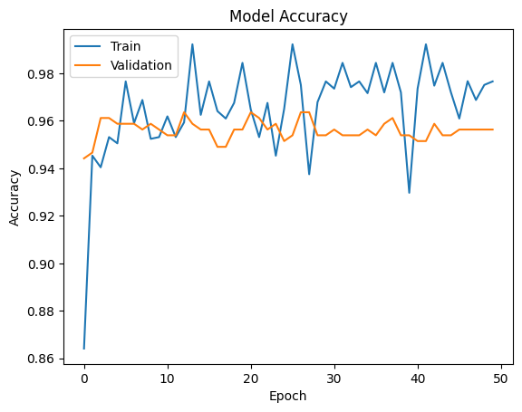

```python
plt.plot(history_vgg16.history['accuracy'])
plt.plot(history_vgg16.history['val_accuracy'])
plt.title('Model Accuracy')
plt.ylabel('Accuracy')
plt.xlabel('Epoch')
plt.legend(['Train', 'Validation'], loc='upper left')
plt.show()
```

```python
# Evaluate on Train Set
model_2_train_perf = model_performance_classification(model_2, X_train_normalized,y_train_encoded)

print("Train performance metrics")
print(model_2_train_perf)
```

```
104/104 ━━━━━━━━━━━━━━━━━━━━ 2s 17ms/step
Train performance metrics
   Accuracy    Recall  Precision  F1 Score
0  0.993636  0.993636   0.993636  0.993636
```

```python
plot_confusion_matrix(model_2, X_train_normalized, y_train_encoded)
```

[output not shown]

```python
model_2_valid_perf = model_performance_classification(model_2, X_val_normalized,y_val_encoded)

print("Validation performance metrics")
print(model_2_valid_perf)
```

```
13/13 ━━━━━━━━━━━━━━━━━━━━ 0s 17ms/step
Validation performance metrics
   Accuracy    Recall  Precision  F1 Score
0  0.956311  0.956311   0.956311  0.956311
```

```
13/13 ━━━━━━━━━━━━━━━━━━━━ 0s 20ms/step
```

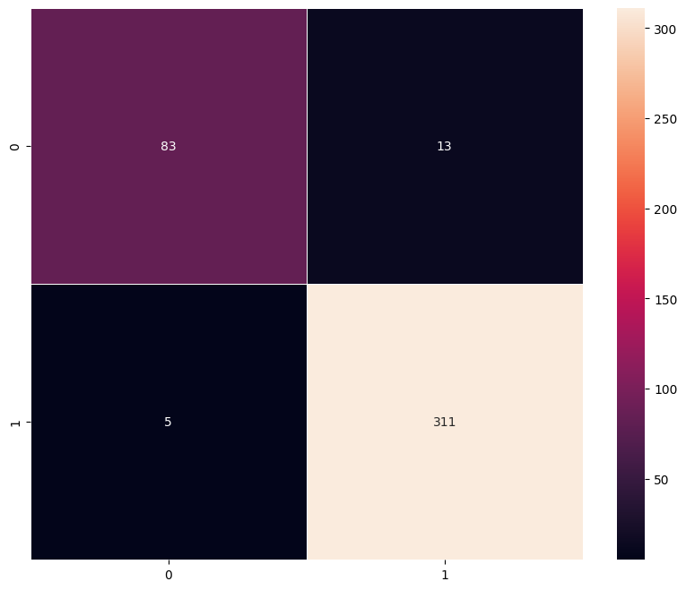

```python
plot_confusion_matrix(model_2,X_val_normalized,y_val_encoded)
```

it is approx 95% accuracy

### Visualizing the predictions

[output not shown]

[figure not shown]

```
1/1 ━━━━━━━━━━━━━━━━━━━━ 0s 50ms/step
Predicted Label [1]
True Label 1
```

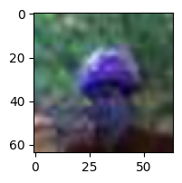

```
1/1 ━━━━━━━━━━━━━━━━━━━━ 0s 52ms/step
Predicted Label [1]
True Label 1
```

```python
# Visualizing the predicted and correct label of images from test data
plt.figure(figsize=(2,2))
plt.imshow(X_val[2])
plt.show()
print('Predicted Label', enc.inverse_transform(model_1.predict((X_val_normalized[2].reshape(1,64,64,3)))))   # reshaping the input image as we are only trying to predict using a single image
print('True Label', enc.inverse_transform(y_val_encoded)[2])                                               # using inverse_transform() to get the output label from the output vector

plt.figure(figsize=(2,2))
plt.imshow(X_val[10])
plt.show()
print('Predicted Label', enc.inverse_transform(model_1.predict((X_val_normalized[10].reshape(1,64,64,3)))))  # reshaping the input image as we are only trying to predict using a single image
print('True Label', enc.inverse_transform(y_val_encoded)[10])                                              # using inverse_transform() to get the output label from the output vector

plt.figure(figsize=(2,2))
plt.imshow(X_val[23])
plt.show()
print('Predicted Label', enc.inverse_transform(model_1.predict((X_val_normalized[23].reshape(1,64,64,3)))))  # reshaping the input image as we are only trying to predict using a single image
print('True Label', enc.inverse_transform(y_val_encoded)[23])
```

- In most of the real-world case studies, it is challenging to acquire a large number of images and then train CNNs.
- To overcome this problem, one approach we might consider is **Data Augmentation**.
- CNNs have the property of **translational invariance**, which means they can recognise an object even if its appearance shifts translationally in some way. - Taking this attribute into account, we can augment the images using the techniques listed below
  - Horizontal Flip (should be set to True/False)
  - Vertical Flip (should be set to True/False)
  - Height Shift (should be between 0 and 1)
  - Width Shift (should be between 0 and 1)
  - Rotation (should be between 0 and 180)
  - Shear (should be between 0 and 1)
  - Zoom (should be between 0 and 1) etc.

Remember, **data augmentation should not be used in the validation/test data set**.

```python
model_3 = Sequential()

# Adding the convolutional part of the VGG16 model from above
model_3.add(vgg_model)

# Flattening the output of the VGG16 model because it is from a convolutional layer
model_3.add(Flatten())

#Adding the Feed Forward neural network
model_3.add(Dense(256,activation='relu'))
model_3.add(Dropout(rate=0.4))
model_3.add(Dense(32,activation='relu'))

# Adding a dense output layer for binary classification
model_3.add(Dense(1, activation='sigmoid'))
```

```python
opt=Adam()
# Compile model for binary classification
model_3.compile(optimizer=opt, loss='binary_crossentropy', metrics=['accuracy'])
```

```python
# Generating the summary of the model
model_3.summary()
```

```
Model: "sequential_4"
```

```
┏━━━━━━━━━━━━━━━━━━━━━━━━━━━━━━━━━┳━━━━━━━━━━━━━━━━━━━━━━━━┳━━━━━━━━━━━━━━━┓
┃ Layer (type)                    ┃ Output Shape           ┃       Param # ┃
┡━━━━━━━━━━━━━━━━━━━━━━━━━━━━━━━━━╇━━━━━━━━━━━━━━━━━━━━━━━━╇━━━━━━━━━━━━━━━┩
│ vgg16 (Functional)              │ (None, 2, 2, 512)      │    14,714,688 │
├─────────────────────────────────┼────────────────────────┼───────────────┤
│ flatten_4 (Flatten)             │ (None, 2048)           │             0 │
├─────────────────────────────────┼────────────────────────┼───────────────┤
│ dense_11 (Dense)                │ (None, 256)            │       524,544 │
├─────────────────────────────────┼────────────────────────┼───────────────┤
│ dropout_4 (Dropout)             │ (None, 256)            │             0 │
├─────────────────────────────────┼────────────────────────┼───────────────┤
│ dense_12 (Dense)                │ (None, 32)             │         8,224 │
├─────────────────────────────────┼────────────────────────┼───────────────┤
│ dense_13 (Dense)                │ (None, 1)              │            33 │
└─────────────────────────────────┴────────────────────────┴───────────────┘
```

```
 Total params: 15,247,489 (58.16 MB)
```

```
 Trainable params: 7,612,225 (29.04 MB)
```

```
 Non-trainable params: 7,635,264 (29.13 MB)
```

```python
# Applying data augmentation
train_datagen = ImageDataGenerator(
                              rotation_range=20,
                              fill_mode='nearest',width_shift_range=0.2,height_shift_range=0.2,shear_range=0.3,zoom_range=0.4
                              )
```

```python
history_vgg16 = model_3.fit(train_datagen.flow(X_train_normalized,y_train_encoded,
                                       batch_size=batch_size,
                                       seed=42,
                                       shuffle=False),
                    epochs=epochs,
                    steps_per_epoch=X_train_normalized.shape[0] // batch_size,
                    validation_data=(X_val_normalized,y_val_encoded),
                    verbose=1)
```

```
25/25 ━━━━━━━━━━━━━━━━━━━━ 9s 277ms/step - accuracy: 0.9209 - loss: 0.1885 - val_accuracy: 0.9515 - val_loss: 0.1674
25/25 ━━━━━━━━━━━━━━━━━━━━ 0s 10ms/step - accuracy: 0.9766 - loss: 0.0655 - val_accuracy: 0.9490 - val_loss: 0.2131
25/25 ━━━━━━━━━━━━━━━━━━━━ 5s 209ms/step - accuracy: 0.9540 - loss: 0.1153 - val_accuracy: 0.9417 - val_loss: 0.2348
25/25 ━━━━━━━━━━━━━━━━━━━━ 1s 14ms/step - accuracy: 0.9609 - loss: 0.1060 - val_accuracy: 0.9466 - val_loss: 0.2190
25/25 ━━━━━━━━━━━━━━━━━━━━ 7s 272ms/step - accuracy: 0.9600 - loss: 0.1030 - val_accuracy: 0.9539 - val_loss: 0.1510
25/25 ━━━━━━━━━━━━━━━━━━━━ 0s 10ms/step - accuracy: 0.9688 - loss: 0.1058 - val_accuracy: 0.9660 - val_loss: 0.1199
25/25 ━━━━━━━━━━━━━━━━━━━━ 8s 305ms/step - accuracy: 0.9596 - loss: 0.1056 - val_accuracy: 0.9563 - val_loss: 0.1550
25/25 ━━━━━━━━━━━━━━━━━━━━ 1s 12ms/step - accuracy: 0.9531 - loss: 0.1349 - val_accuracy: 0.9660 - val_loss: 0.1349
25/25 ━━━━━━━━━━━━━━━━━━━━ 6s 248ms/step - accuracy: 0.9663 - loss: 0.0944 - val_accuracy: 0.9587 - val_loss: 0.1624
25/25 ━━━━━━━━━━━━━━━━━━━━ 0s 11ms/step - accuracy: 0.9766 - loss: 0.0630 - val_accuracy: 0.9636 - val_loss: 0.1585
25/25 ━━━━━━━━━━━━━━━━━━━━ 5s 213ms/step - accuracy: 0.9596 - loss: 0.1111 - val_accuracy: 0.9490 - val_loss: 0.1234
25/25 ━━━━━━━━━━━━━━━━━━━━ 0s 11ms/step - accuracy: 0.9609 - loss: 0.1427 - val_accuracy: 0.9587 - val_loss: 0.1254
25/25 ━━━━━━━━━━━━━━━━━━━━ 7s 280ms/step - accuracy: 0.9663 - loss: 0.0865 - val_accuracy: 0.9515 - val_loss: 0.1776
25/25 ━━━━━━━━━━━━━━━━━━━━ 0s 10ms/step - accuracy: 0.9375 - loss: 0.0990 - val_accuracy: 0.9515 - val_loss: 0.1659
25/25 ━━━━━━━━━━━━━━━━━━━━ 5s 207ms/step - accuracy: 0.9656 - loss: 0.0908 - val_accuracy: 0.9539 - val_loss: 0.1457
25/25 ━━━━━━━━━━━━━━━━━━━━ 0s 10ms/step - accuracy: 0.9844 - loss: 0.0436 - val_accuracy: 0.9587 - val_loss: 0.1584
25/25 ━━━━━━━━━━━━━━━━━━━━ 7s 279ms/step - accuracy: 0.9644 - loss: 0.0895 - val_accuracy: 0.9490 - val_loss: 0.1496
25/25 ━━━━━━━━━━━━━━━━━━━━ 0s 10ms/step - accuracy: 0.9609 - loss: 0.1200 - val_accuracy: 0.9490 - val_loss: 0.1363
25/25 ━━━━━━━━━━━━━━━━━━━━ 5s 210ms/step - accuracy: 0.9650 - loss: 0.0838 - val_accuracy: 0.9539 - val_loss: 0.1929
25/25 ━━━━━━━━━━━━━━━━━━━━ 0s 10ms/step - accuracy: 0.9688 - loss: 0.1237 - val_accuracy: 0.9563 - val_loss: 0.1801
```

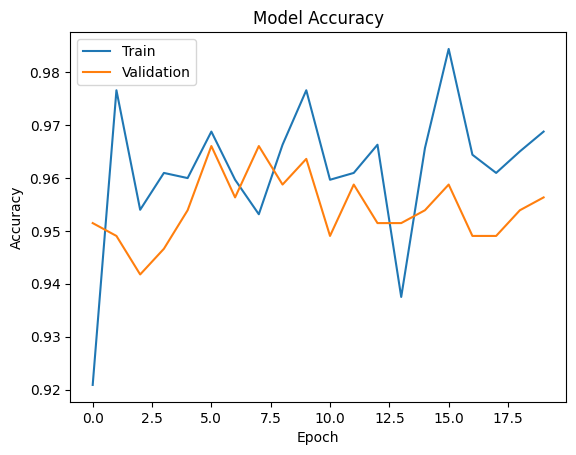

```python
plt.plot(history_vgg16.history['accuracy'])
plt.plot(history_vgg16.history['val_accuracy'])
plt.title('Model Accuracy')
plt.ylabel('Accuracy')
plt.xlabel('Epoch')
plt.legend(['Train', 'Validation'], loc='upper left')
plt.show()
```

```python
model_3_train_perf = model_performance_classification(model_3, X_train_normalized,y_train_encoded)

print("Train performance metrics")
print(model_3_train_perf)
```

```
104/104 ━━━━━━━━━━━━━━━━━━━━ 2s 17ms/step
Train performance metrics
   Accuracy    Recall  Precision  F1 Score
0  0.993333  0.993333   0.993333  0.993333
```

```
104/104 ━━━━━━━━━━━━━━━━━━━━ 2s 15ms/step
```

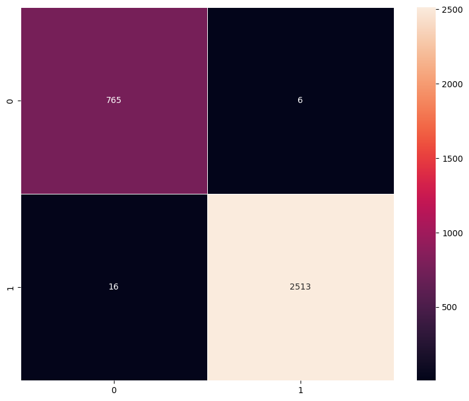

```python
plot_confusion_matrix(model_3,X_train_normalized,y_train_encoded)
```

```python
model_3_valid_perf = model_performance_classification(model_3, X_val_normalized,y_val_encoded)

print("Validation performance metrics")
print(model_3_valid_perf)
```

```
13/13 ━━━━━━━━━━━━━━━━━━━━ 0s 16ms/step
Validation performance metrics
   Accuracy    Recall  Precision  F1 Score
0  0.956311  0.956311   0.956311  0.956311
```

```
13/13 ━━━━━━━━━━━━━━━━━━━━ 0s 16ms/step
```

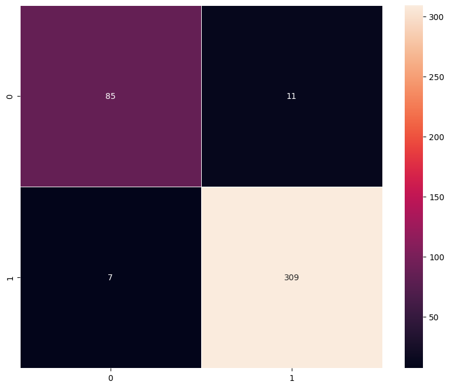

```python
plot_confusion_matrix(model_3,X_val_normalized,y_val_encoded)
```

Visualizing the prediction:

```
1/1 ━━━━━━━━━━━━━━━━━━━━ 0s 46ms/step
Predicted Label [0]
True Label 0
```

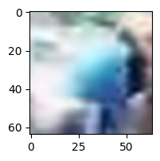

```
1/1 ━━━━━━━━━━━━━━━━━━━━ 0s 46ms/step
Predicted Label [1]
True Label 1
```

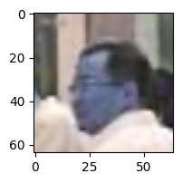

```
1/1 ━━━━━━━━━━━━━━━━━━━━ 0s 47ms/step
Predicted Label [0]
True Label 0
```

```python
# Visualizing the predicted and correct label of images from test data
plt.figure(figsize=(2,2))
plt.imshow(X_val[2])
plt.show()
print('Predicted Label', enc.inverse_transform(model_3.predict((X_val_normalized[2].reshape(1,64,64,3)))))   # reshaping the input image as we are only trying to predict using a single image
print('True Label', enc.inverse_transform(y_val_encoded)[2])                                               # using inverse_transform() to get the output label from the output vector

plt.figure(figsize=(2,2))
plt.imshow(X_val[33])
plt.show()
print('Predicted Label', enc.inverse_transform(model_3.predict((X_val_normalized[33].reshape(1,64,64,3)))))  # reshaping the input image as we are only trying to predict using a single image
print('True Label', enc.inverse_transform(y_val_encoded)[33])                                              # using inverse_transform() to get the output label from the output vector

plt.figure(figsize=(2,2))
plt.imshow(X_val[36])
plt.show()
print('Predicted Label', enc.inverse_transform(model_3.predict((X_val_normalized[36].reshape(1,64,64,3)))))  # reshaping the input image as we are only trying to predict using a single image
print('True Label', enc.inverse_transform(y_val_encoded)[36])
```

# **Model Performance Comparison and Final Model Selection**

```python
#training performance comparison

models_train_comp_df = pd.concat(
    [
        cnn_model_1_train_perf.T,
        model_1_train_perf.T,
        model_2_train_perf.T,
        model_3_train_perf.T,
    ],
    axis=1,
)
models_train_comp_df.columns = [
    "VGG-16 (CNN)","VGG-16 (Base)","VGG-16 (Base+FFNN)","VGG-16 (Base+FFNN+Data Aug)"
]
```

```python
models_valid_comp_df = pd.concat(
    [
        cnn_model_1_val_perf.T,
        model_1_valid_perf.T,
        model_2_valid_perf.T,
        model_3_valid_perf.T,
    ],
    axis=1,
)
models_valid_comp_df.columns = [
    "VGG-16 (CNN)","VGG-16 (Base)","VGG-16 (Base+FFNN)","VGG-16 (Base+FFNN+Data Aug)"
]
```

```python
models_train_comp_df
```

|  | VGG-16 (CNN) | VGG-16 (Base) | VGG-16 (Base+FFNN) | VGG-16 (Base+FFNN+Data Aug) |
| --- | --- | --- | --- | --- |
| Accuracy | 0.988182 | 0.965152 | 0.993636 | 0.993333 |
| Recall | 0.988182 | 0.965152 | 0.993636 | 0.993333 |
| Precision | 0.988182 | 0.965152 | 0.993636 | 0.993333 |
| F1 Score | 0.988182 | 0.965152 | 0.993636 | 0.993333 |

```python
models_valid_comp_df
```

|  | VGG-16 (CNN) | VGG-16 (Base) | VGG-16 (Base+FFNN) | VGG-16 (Base+FFNN+Data Aug) |
| --- | --- | --- | --- | --- |
| Accuracy | 0.90534 | 0.953883 | 0.956311 | 0.956311 |
| Recall | 0.90534 | 0.953883 | 0.956311 | 0.956311 |
| Precision | 0.90534 | 0.953883 | 0.956311 | 0.956311 |
| F1 Score | 0.90534 | 0.953883 | 0.956311 | 0.956311 |

```python
models_train_comp_df - models_valid_comp_df
```

|  | VGG-16 (CNN) | VGG-16 (Base) | VGG-16 (Base+FFNN) | VGG-16 (Base+FFNN+Data Aug) |
| --- | --- | --- | --- | --- |
| Accuracy | 0.082842 | 0.011268 | 0.037326 | 0.037023 |
| Recall | 0.082842 | 0.011268 | 0.037326 | 0.037023 |
| Precision | 0.082842 | 0.011268 | 0.037326 | 0.037023 |
| F1 Score | 0.082842 | 0.011268 | 0.037326 | 0.037023 |

## Test Performance

```python
model_2_test_perf = model_performance_classification(model_2, X_test_normalized,y_test_encoded)
```

```
13/13 ━━━━━━━━━━━━━━━━━━━━ 0s 18ms/step
```

```python
display(model_2_test_perf)
```

|  | Accuracy | Recall | Precision | F1 Score |
| --- | --- | --- | --- | --- |
| 0 | 0.937046 | 0.937046 | 0.937046 | 0.937046 |

```
13/13 ━━━━━━━━━━━━━━━━━━━━ 0s 16ms/step
```

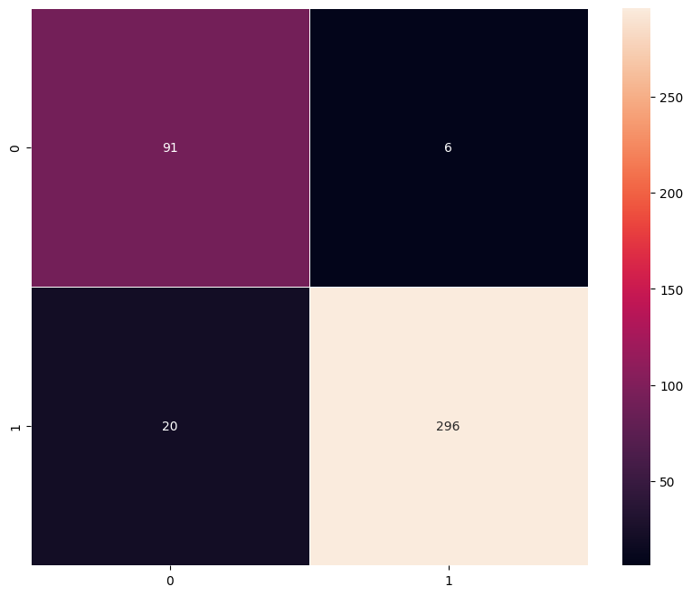

```python
plot_confusion_matrix(model_2, X_test_normalized,y_test_encoded)
```

VGG-16 (Base+FFNN) has achieved the highest performance on both the training and validation sets.

We will proceed with VGG-16 (Base+FFNN) as our final model.

# **Actionable Insights & Recommendations**

The system can be used for real-time helmet detection, reducing manual monitoring and improving workplace safety.

Even small errors in detecting “no helmet” cases are critical, so continuous improvement is required.

### Recommendations:

Deploy the model with CCTV systems for real-time alerts Retrain regularly with new data to improve accuracy Increase “no helmet” data to reduce safety risks

Data Augmentation can be performed more and dropout_rate can be changed to improve the model performance.

Power Ahead!